### ✅ Put your name here.

#### ✅ Put your group member names here.

# Day 20 In-Class Assignment

## Are Western Corn Rootworm attacks statistically different across corn genotypes and soil treatments?

[figure not shown]

For this in-class, we will continue working on the data related to the western corn rootworm (WCR) and its feeding behavior. As mentioned in the pre-class, this data comes from [recently published MU research](https://doi.org/10.1007/s10340-023-01725-2).

The **learning goals** of the assignment are to:

- Determine whether WCR larval weights are statistically different under different growth and treatment conditions.
- Partly reproduce the bar plots of Figure 2 of the reference paper.

> Paddock, K.J., Veum, K.S., Finke, D.L. Ericsson, A.C., and Hibbard, B.E. (2024) [Soil microbes from conservation agriculture systems reduce growth of Bt-resistant western corn rootworm larvae](https://doi.org/10.1007/s10340-023-01725-2). *J Pest Sci 97*, 1677–1689

## Assignment instructions

Work with your group to complete this assignment. Instructions for submitting this assignment are at the end of the notebook. The assignment is due at the end of class.

```python
# Import all needed libraries at first

import os
import pandas as pd
import numpy as np
import matplotlib.pyplot as plt
from scipy import stats
```

## Load and explore the data

### 1.1 Load and explore the data

Just like last time, let's start by loading the appropriate dataset, `'210602_fitness_data.csv'`. **Make sure you are using the CSV provided in the last in-class**. (There is a small mistake in the publicly available dataset).

**Task**

- Use Pandas to load the CSV as a DataFrame.
- Display the first 5 rows with `.head`
- Which columns might relate to [Figure 2](https://link.springer.com/article/10.1007/s10340-023-01725-2/figures/2) of the reference paper? (It's ok if you don't figure it out quickly: we'll discuss it later.)
- This time, make sure to remove any rows with NaNs in the `root_dw` column. (No columns will be actually removed, but it is important to double check.)
- Do **not** remove rows with NaN in the `weight_per_larvae` column like last time. We'll need the "control experiment" rows that had no larvae to begin with.

```python
# Your code
```

```python
# ANSWER

src = '..' + os.sep + 'raw' + os.sep

full_fit = pd.read_csv(src + '210602_fitness_data.csv')
#fit = full_fit.copy()
fit = full_fit.loc[ ~ pd.isna(full_fit['root_dw']) ].copy()

treats = fit['treatment'].unique()
traits = fit['corn_trait'].unique()
colonies = fit['colony'].unique()
print(full_fit.shape, fit.shape, treats, traits, colonies, sep='\n')
ymax = 1000*(fit['root_dw']/fit['seed_num']).max()
fit.head()
```

```
(144, 21)
(144, 21)
['CC' 'TR']
['ISO' 'BT']
['SUS' 'RES' 'CTRL']
```

|  | experiment | tube | treatment | corn_trait | colony | block | rep | larv_surv | hcw1 | hcw2 | ... | hcw4 | hcw5 | hcw6 | Average | HCW_20 | total_larva_weighed | larv_dw | weight_per_larvae | root_dw | seed_num |
| --- | --- | --- | --- | --- | --- | --- | --- | --- | --- | --- | --- | --- | --- | --- | --- | --- | --- | --- | --- | --- | --- |
| 0 | 21KYL | 5 | CC | ISO | SUS | 1 | 1 | 4.0 | 6.5 | 7.0 | ... | 6.5 | NaN | NaN | 6.000 | 0.300 | 4.0 | 0.289 | 0.072250 | 0.19005 | 2 |
| 1 | 21KYL | 13 | CC | ISO | RES | 1 | 1 | 5.0 | 6.0 | 7.0 | ... | 7.0 | 6.0 | NaN | 6.700 | 0.335 | 5.0 | 0.855 | 0.171000 | 0.12659 | 2 |
| 2 | 21KYL | 29 | CC | ISO | SUS | 1 | 2 | 3.0 | 6.0 | 5.5 | ... | NaN | NaN | NaN | 5.833 | 0.292 | 3.0 | 0.271 | 0.090333 | 0.11213 | 2 |
| 3 | 21KYL | 37 | CC | ISO | RES | 1 | 2 | 0.0 | NaN | NaN | ... | NaN | NaN | NaN | NaN | NaN | 0.0 | NaN | NaN | 0.15135 | 2 |
| 4 | 21KYL | 49 | CC | ISO | SUS | 1 | 3 | 5.0 | 7.0 | 6.0 | ... | 6.0 | 7.0 | NaN | 6.400 | 0.320 | 5.0 | 0.485 | 0.097000 | 0.23612 | 2 |

5 rows × 21 columns

### 1.2 Relating columns to figures

Let's look again at [Figure 2](https://link.springer.com/article/10.1007/s10340-023-01725-2/figures/2) and let's relate it to the data:

For Figure 2a:

- The Y-axis is "Root weight" *per plant*, so it is `root_dw` *divided* by `seed_num` (number of seedlings).
- `root_dw` is in grams. We'll have to multiply it by 1000 to get miligrams instead.
- The point scatters are split into Conservational or Traditional soil management practices, encoded as `CC` or `TR`, respectively, in the `treatment` column.
- They are also differentiated into Bt-expressing transgenic corn line or not, encoded as `BT` or `ISO`, respectively, in the `corn_trait` column.
- Notice that the plot does not split data into Bt-susceptible or -resistant WCR larvae.

For Figure 2b:

- The Y-axis is the logarithm of the ratio of root weight of "fed (worm eaten/munched) roots" to "unfed (not eaten) roots".
- The "fed roots" are those from experiments involving larvae, either `SUS` or `RES`.
- The "unfed roots" are those from `CTRL` control experiments involving no larvae.

**Task**

Let's focus on the first scatter of Figure 2a. With Pandas:

- Define a new DataFrame that contains the information for conservational soil practice **and** BT-expressing corn line **and** *either* Bt-susceptible or -resistant larvae.
  - *Hint*: The last condition is equivalent to look for non-control rows.
- Define a new Series consisting root weight *per* plant (or seedling).
- Multiply the Series by 1000 to have miligrams instead of grams.
- Compute and print the mean (with `.mean`) and standard error (with `.sem`) of this Series.
- **Note**: The Figure 2 in the paper is wrong; however, the corrected version was not updated. You'll get different results in your figure. The actual mean and standard error values are

```
106.34770833333334 6.471887289554156
```

```python
# Your code
```

```python
treat = 'CC'
trait = 'BT'

df = fit[ (fit['treatment'] == treat) & (fit['corn_trait'] == trait) & (fit['colony'] != 'CTRL') ]
rw = 1000*(df['root_dw']/df['seed_num'])
print(rw.mean(), rw.sem())
```

```
106.34770833333334 6.471887289554156
```

### 1.3 Determining differences: Visualization

Let's check if there's a root weight difference between conservational and traditional soil treatments. Remember to always visualize your data before performing any statistics.

**Task**

- Make a new Series like (1.2) where you look at the traditional soil regime data instead.
- Display both series as two boxplots.
- Plot a scatter plot of both Series.
  - Remember to add some random perturbations to the scatter so it is easier to visualize different datapoints like we did in the past in-class.
- Do you think it the population are different?

```python
# Your code here
```

```python
## ANSWER

rng = np.random.default_rng(seed=42)
eps = rng.uniform(-0.25,0.25,1000)

trait = 'BT'

treat = 'CC'
df = fit[ (fit['treatment'] == treat) & (fit['corn_trait'] == trait) & (fit['colony'] != 'CTRL') ]
w1 = 1000*(df['root_dw']/df['seed_num'])

treat = 'TR'
df = fit[ (fit['treatment'] == treat) & (fit['corn_trait'] == trait) & (fit['colony'] != 'CTRL') ]
w2 = 1000*(df['root_dw']/df['seed_num'])
```

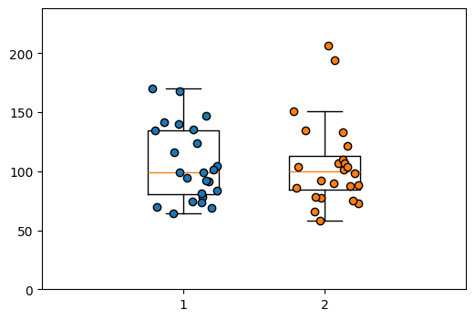

```python
fig, ax = plt.subplots(figsize=(6,4))

ax.boxplot([w1,w2], widths=0.5, sym='', zorder=1)
ax.scatter(eps[:len(w1)] + 1, w1, edgecolor='k', zorder=2)
ax.scatter(eps[:len(w2)] + 2, w2, edgecolor='k', zorder=2)

ax.set_xlim(0,3)
ax.set_ylim(0, ymax);
```

Do the points and boxplots suggest the populations (conservational vs traditional soil regime) are different?

### 1.4 Determining differences: Statistics

The visualizations suggest that the populations are not that different. Let's use statistics to confirm our intuition.

**Task**

- With `stats.mannwhitneyu`, check wheter these two populations are statistically different.
- Does the test confirm your intuition?

```python
# Your code here
```

```python
# ANSWER
print( stats.mannwhitneyu(w1, w2) )
```

```
MannwhitneyuResult(statistic=297.0, pvalue=0.8608698044170195)
```

### 1.5 Check the rest

- Repeat parts (1.4) and (1.5), but this time, look at the non-Bt-expressing corn line. Is there a difference in root weight with soil treatments when using the non-Bt corn type?

### 1.6 Plotting results: scatter plot

Now let's reproduce the scatter plot from Figure 2a. Let's get first the four "columns": the four subsets of scatter points.

**Task**

The scatter plot requires all data points, so a summary DataFrame will not work. Like in the pre-class, it will be better to define a few lists (of 4 elements each because we seek to plot 4 scatters in the same plot) with position and color information.

- Define a list with corn traits.
  - To follow the order of Figure 2a, this list should be `['BT','BT','ISO','ISO']`
- Define a list of soil treatments following the same order of Figure 2a.
- - Define a list with colors, one per "column".
- Define a list of x-axis positions for the "columns".
- Then loop and find the appropriate subset of data for each "column". Use the index to grab the appropriate values from each of the lists you have just defined.

```
for j in range(len(`list_name`)):
    # Your code from (1.2) to get the right subset of data
    # Then part of your code from (1.3) to get a scatter plot
```

```python
# Your code
```

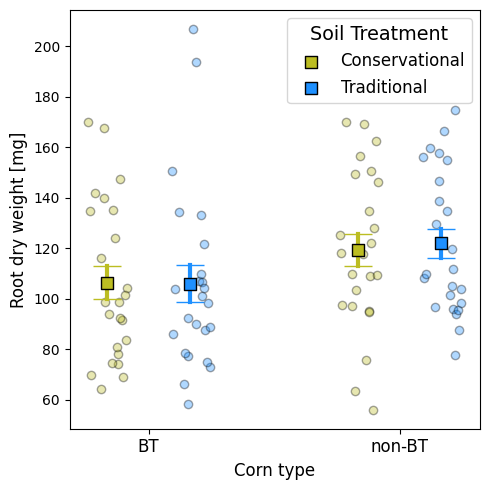

```python
## ANSWER
fs = 12
color = ['tab:olive', 'dodgerblue', 'tab:olive', 'dodgerblue']
trait = ['BT','BT','ISO','ISO']
treat = ['CC','TR','CC','TR']
xvals = [0,1,3,4]

fig, ax = plt.subplots(figsize=(5,5))

for j in range(len(xvals)):
    df = fit[ (fit['treatment'] == treat[j]) & (fit['corn_trait'] == trait[j]) & (fit['colony'] != 'CTRL') ]
    rw = 1000*(df['root_dw']/df['seed_num'])
    avg, sem = rw.mean(), rw.sem()
    ax.scatter(eps[:len(rw)]+xvals[j], rw, color=color[j], alpha=0.35, ec='k', zorder=1)
    ax.plot( 2*[xvals[j]], [avg - sem, avg+sem], lw=3, c=color[j], marker='_', ms=20)
    ax.scatter(xvals[j], avg, color=color[j], marker='s', s=80, edgecolor='k', zorder=3, label=j)

h,l = ax.get_legend_handles_labels()
ax.legend(h[:2],['Conservational','Traditional'], title='Soil Treatment', title_fontsize=1.15*fs, fontsize=fs)
ax.set_xticks([0.5, 3.5], ['BT','non-BT'], fontsize=fs)
ax.set_xlabel('Corn type', fontsize=fs)
ax.set_ylabel('Root dry weight [mg]', fontsize=fs)
fig.tight_layout();
```

### 1.7 Plotting results: means and standard errors

Now we need to add the mean and error bars.

**Task**

- Copy the code from (1.6) below.
- With `.scatter`, add single point representing the mean of the "column".
- With `.plot`, draw a line corresponding to the standard error.
  - `.plot` requires you to specify x- and y-coordinates of the line
  - The error line will go from `(x , avg - sem)` to `(x , avg + sem)`, where `x` is the x-axis position of the column, `avg` is the mean, and `sem` is the standard error.
  - Have the parameters `marker = '_', ms=20` to add a horizontal line at the ends of the error bars.

```python
# Enhance your plot
```

## 1.8 Plotting results: labels

Finally, copy your code from (1.7) and add appropriate x- and y-labels. Change the x-ticks as well. No need to have a legend.

```python
# Your final plot
```

### Congratulations, you're done!

Submit this assignment by uploading it to the course Canvas web page. Go to the "Assignments" folder, find the appropriate submission folder link, and upload it there.

© Copyright 2025, Division of Plant Science & Technology—University of Missouri